# A global analysis of complexity–biodiversity relationships on marine artificial structures - Strain - 2021 - Global Ecology and Biogeography - Wiley Online Library

[Global Ecology and Biogeography](https://onlinelibrary.wiley.com/journal/14668238)

[Volume 30, Issue 1](https://onlinelibrary.wiley.com/toc/14668238/2021/30/1) p. 140-153

[figure not shown]

RESEARCH PAPER

Full Access

# A global analysis of complexity–biodiversity relationships on marine artificial structures

[Elisabeth M. A. Strain](https://onlinelibrary.wiley.com/action/doSearch?ContribAuthorStored=Strain%2C+Elisabeth+M+A)

[Peter D. Steinberg](https://onlinelibrary.wiley.com/action/doSearch?ContribAuthorStored=Steinberg%2C+Peter+D)

[Maria Vozzo](https://onlinelibrary.wiley.com/action/doSearch?ContribAuthorStored=Vozzo%2C+Maria)

[Emma L. Johnston](https://onlinelibrary.wiley.com/action/doSearch?ContribAuthorStored=Johnston%2C+Emma+L)

[Marco Abbiati](https://onlinelibrary.wiley.com/action/doSearch?ContribAuthorStored=Abbiati%2C+Marco)

[Moises A. Aguilera](https://onlinelibrary.wiley.com/action/doSearch?ContribAuthorStored=Aguilera%2C+Moises+A)

[Laura Airoldi](https://onlinelibrary.wiley.com/action/doSearch?ContribAuthorStored=Airoldi%2C+Laura)

[J. David Aguirre](https://onlinelibrary.wiley.com/action/doSearch?ContribAuthorStored=Aguirre%2C+J+David)

[Gail Ashton](https://onlinelibrary.wiley.com/action/doSearch?ContribAuthorStored=Ashton%2C+Gail)

[Maritina Bernardi](https://onlinelibrary.wiley.com/action/doSearch?ContribAuthorStored=Bernardi%2C+Maritina)

… See all authors

First published: 20 October 2020

https://doi.org/10.1111/geb.13202

**Funding information**This project was part of the World Harbour Project. We thank the various funding bodies (see Supporting Information S9 for full details). Ministry of Science and Technology, Taiwan; Academia Sinica Senior Investigator Award, Taiwan; Academia Sinica Post‐doctoral Fellowship, Taiwan; National Research Foundation (South Africa).

## Abstract

### Aim

Topographic complexity is widely accepted as a key driver of biodiversity, but at the patch‐scale, complexity–biodiversity relationships may vary spatially and temporally according to the environmental stressors complexity mitigates, and the species richness and identity of potential colonists. Using a manipulative experiment, we assessed spatial variation in patch‐scale effects of complexity on intertidal biodiversity.

### Location

27 sites within 14 estuaries/bays distributed globally.

### Time period

2015–2017.

### Major taxa studied

Functional groups of algae, sessile and mobile invertebrates.

### Methods

Concrete tiles of differing complexity (flat; 2.5‐cm or 5‐cm complex) were affixed at low–high intertidal elevation on coastal defence structures, and the richness and abundance of the colonizing taxa were quantified after 12 months.

### Results

The patch‐scale effects of complexity varied spatially and among functional groups. Complexity had neutral to positive effects on total, invertebrate and algal taxa richness, and invertebrate abundances. However, effects on the abundance of algae ranged from positive to negative, depending on location and functional group. The tidal elevation at which tiles were placed accounted for some variation. The total and invertebrate richness were greater at low or mid than at high intertidal elevations. Latitude was also an important source of spatial variation, with the effects of complexity on total richness and mobile mollusc abundance greatest at lower latitudes, whilst the cover of sessile invertebrates and sessile molluscs responded most strongly to complexity at higher latitudes.

### Conclusions

After 12 months, patch‐scale relationships between biodiversity and habitat complexity were not universally positive. Instead, the relationship varied among functional groups and according to local abiotic and biotic conditions. This result challenges the assumption that effects of complexity on biodiversity are universally positive. The variable effect of complexity has ramifications for community and applied ecology, including eco‐engineering and restoration that seek to bolster biodiversity through the addition of complexity.

## 1 INTRODUCTION

Habitat complexity, the physical structure of environments, is a key driver of variability in the distribution of biodiversity (Huston, 1979; Kovalenko et al., 2012). In general, more complex habitats, with a greater density of spatial elements, support greater species richness and abundance, across a range of functional groups, than less complex habitats (McCoy & Bell, 1991; Stein et al., 2014). Habitat complexity may be derived from both topographic (e.g., undulations, depressions and protrusions) or biogenic (e.g., trees, grasses, seaweeds, ants, corals and bivalves) structures. Complex habitats can influence the colonization and subsequent survival of species by determining the area available for organisms to occupy (Connor & McCoy, 1979), which in turn can influence biotic interactions (Hixon & Beets, 1993; Holt, 1987). Complex habitats can also have area‐independent effects on niche diversity (Johnson et al., 2003), and consequently influence the availability of refuges from environmental stressors and predators (Strain et al., 2020). At land‐ and sea‐scape scales complexity enhances biodiversity by increasing habitat heterogeneity and niche space (Kovalenko et al., 2012). However, at smaller scales, biodiversity and habitat complexity relationships may vary depending on the type of complexity provided and how it interacts with the environmental and biological setting (Loke & Todd, 2016).

The environmental variation among sites at local and biogeographic scales may influence patch‐scale habitat complexity (hereafter complexity)–biodiversity relationships by determining resource availability, environmental conditions, as well as the species pool on which complexity can act (Bracewell et al., 2018; Johnson et al., 2003). The stress gradient hypothesis (Bertness & Callaway, 1994) proposes that positive interactions among species (e.g., between habitat‐forming and dependent taxa) will be most prevalent in environmentally stressful environments, where local habitat amelioration is critical to organismal survival (Bracewell et al., 2018; McAfee et al., 2016). Hence, microhabitats that ameliorate extreme temperatures and/or desiccation stressors could increase in importance with increasing tidal elevation (Bateman & Bishop, 2016) and decreasing latitude (Bracewell et al., 2018). Conversely, the patch‐scale effects of complexity may be consistent across latitude if the local species are adapted to their local conditions or could have a greater influence in locations where there is a greater difference between the air and sea temperatures.

Additionally, complexity may be expected to have greatest patch‐scale effects on biodiversity in environments where there is a diverse species pool on which it can act, whereby, the effects of complexity may vary across latitudinal gradients in species richness (Bracewell et al., 2018). At local scales, anthropogenic stressors such as contaminants may over‐ride the effects of complexity when they create conditions that are inhibitory to the survival of most species (Mayer‐Pinto et al., 2016). How species abundance and, hence, richness responds to complexity may also vary according to the dominant functional groups present at a given location (Strain, Olabarria, et al., 2018). Functional groups, defined here as groups of organisms displaying distinct life‐forms, differ in their niche requirements, tolerance to environmental stressors and susceptibility to predation (Micheli & Halpern, 2005). While, overall, increasing complexity is expected to enhance microhabitat diversity and niche space, the availability of some microhabitat types will decline and others will increase with different types of complexity (Kelaher, 2003).

The taxa whose niche requirements are favoured by increasing complexity will benefit at the expense of other taxa whose niche requirements match microhabitats that decline in abundance or area (Malumbres‐Olarte et al., 2013). For example, on intertidal rocky shores, algae can be among the dominant space occupants of well‐lit yet wet microhabitats (e.g., rockpools) that prevent desiccation and allow adequate light for photosynthesis (Wilson et al., 1992). In contrast, mobile invertebrates, particularly sessile invertebrates, will benefit from microhabitats (e.g., crevices) that provide protection from predators, but are also sufficiently shaded so that their algal competitors cannot survive (Glasby, 1999; Miller & Etter, 2008). Stress‐sensitive taxa may benefit more than stress‐tolerant taxa, from microhabitats that ameliorate environmental stressors (Darling et al., 2017). Similarly, taxa that are more susceptible to predation (i.e., lack morphological or behavioural defences) or have body sizes that most closely match the size of the microhabitats may benefit most from complexity‐mediated predator amelioration (Strain, Morris, et al., 2018). Experimental research on the effects of increasing complexity on different functional groups (i.e., algae, sessile invertebrates and mobile invertebrates) is lacking (but see Strain et al., 2020).

Few studies have examined the effects of complexity at large spatial scales, across functional groups and the influence of varying environmental contexts, to test the generality of patch‐scale complexity–biodiversity relationships. Understanding how complexity underpins richness and abundance of different taxa and functional groups across a range of environmental conditions is of particular importance, given accelerating habitat loss and homogenization (Kovalenko et al., 2012). In urban marine environments, natural habitats are being replaced by artificial structures (e.g., seawalls, groynes, breakwaters and wharves) with reduced complexity (Airoldi et al., 2009; Bulleri & Chapman, 2010). Such habitat homogenization often occurs simultaneously with other anthropogenically derived environmental changes, such as pollution and/or species invasions (McKinney, 2008). The smooth, relatively homogenous, surfaces of artificial structures typically support fewer native species and individuals (Chapman, 2003), but more non‐native species (Airoldi & Bulleri, 2011) compared to the more complex natural habitats they replace.

There has been increasing interest in how complexity might be incorporated into the design of marine urban structures so as to enhance their ecological value (O’Shaughnessy et al., 2020). The addition of complexity to topographically homogenous marine urban structures has been proposed as a mechanism by which the overall richness and abundances of key functional groups might be enhanced (Strain, Olabarria, et al., 2018). However, the manner in which complexity acts will be context dependent and researchers have recommended that latitudinal and biogeographic considerations are taken into account prior to design or construction (Mayer‐Pinto et al., 2019).

Using standardized experiments on a global scale, we investigated how manipulating one form of complexity (crevices/ridges) on tiles affected the richness and abundance of colonizing taxa at fourteen urban estuaries or bays spread across nine biogeographic realms. We predicted that patch‐scale complexity would have a positive influence on the taxa richness and abundances of all sessile and mobile invertebrate functional groups but not algae, which have higher light requirements, because of greater shading in the crevices (Strain et al., 2020). Furthermore, we expected that the positive effects of increased complexity on richness and abundances of sessile and mobile invertebrates would increase with tidal elevation and with decreasing latitude, as desiccation stress and extreme high temperatures increase, respectively (Bracewell et al., 2018). Finally, we hypothesized that complexity would have a reduced effect on the richness and abundances of sessile and mobile invertebrates in highly polluted environments such as those located near marinas or ports, where the effects of pollution can over‐ride the effects of complexity (Mayer‐Pinto et al., 2016).

## 2 MATERIALS AND METHODS

### 2.1 Study sites

Experimental manipulations were conducted at 27 sites, distributed across 14 locations globally (Figure 1). There were two sites at each location, except for Herzliya Marina, Israel, which hosted a single site. The locations were all in estuaries or bays situated along urbanized coastlines, and were partners in the World Harbour Project ([www.worldharbourproject.com](http://www.worldharbourproject.com/)). Each had a semi‐diurnal tidal regime and well‐mixed marine waters. Within locations, each site comprised a vertical seawall or breakwater that extended from the shallow subtidal or the low intertidal to the high intertidal zone. Sites were at least 0.1 km apart, of variable proximity to port facilities or marinas, and varied in tidal height, tidal range, temperature (average, minimum and maximum) and concentration of heavy metals (see Supporting Information S1).

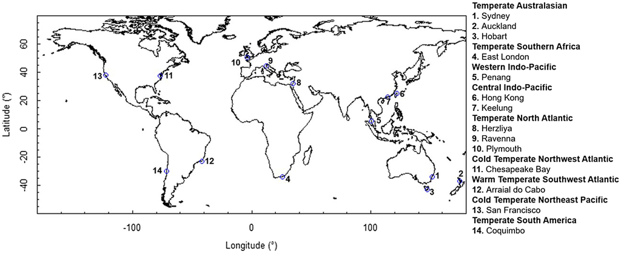

**FIGURE 1**

Map showing the experimental locations. Locations are ordered by biogeographic realm [Colour figure can be viewed at [wileyonlinelibrary.com](https://www.wileyonlinelibrary.com/)]

### 2.2 Experimental design

At each site, 0.25 m × 0.25 m concrete tiles were affixed to the coastal defence structures (i.e., seawalls or breakwaters). The tiles allowed manipulation of intertidal habitat complexity by provisioning crevices and ridges as well as associated increase in surface area. The tiles, designed and manufactured by Reef Design Lab (Melbourne, Australia), were flat (surface area = 0.0625 m<sup>2</sup>), had 0.025‐m‐high ridges separated by 0.015‐ to 0.05‐m‐wide crevices (hereafter ‘2.5‐cm complex’; surface area = 0.090 m<sup>2</sup>) or had 0.05‐m‐high ridges, each separated by 0.015‐ to 0.05‐m‐wide crevices (hereafter ‘5‐cm complex’; surface area = 0.136 m<sup>2</sup>; Figure 2). At each site, five tiles of each design were either directly attached to the structures, in the centre of 0.3 m × 0.3 m patches cleared of pre‐existing flora and fauna, or attached to wood backing boards that were suspended off the top of the structures using rope or nails. Tiles were attached to the structures, backing boards or steel frames using bolts that were placed through a drilled hole in two to four corners of the tiles. At each site, the tiles were deployed in a single horizontal row, from a low to high intertidal elevation, depending on the location. Tiles were deployed in random order with respect to the experimental treatments, with the complex tiles positioned so that the crevices and ridges were orientated vertically. In temperate locations, the tiles were deployed between early spring to late autumn during the period of greatest species recruitment and growth (Supporting Information Table S1; Appendix Data Sources).

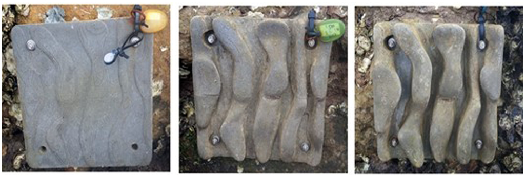

**FIGURE 2**

The three experimental treatments: (a) flat, (b) 2.5‐cm complex, (c) 5‐cm complex [Colour figure can be viewed at [wileyonlinelibrary.com](https://www.wileyonlinelibrary.com/)]

### 2.3 Colonizing taxa

After 12 months, all tiles were removed from the field, individually bagged and frozen until analysis. On each tile, we recorded the identity and percentage cover (pooling across primary and secondary growth) of all sessile algae and invertebrate taxa and removed all mobile invertebrates (> 500 µm), using tweezers and by carefully rinsing the tile area with seawater over a 500‐µm sieve from the whole tile or two subsamples, depending on location (Supporting Information Table S1). At locations where subsampling was conducted, these were from one pre‐determined crevice (0.016 m<sup>2</sup>) and one ridge (0.013 m<sup>2</sup>) of each complex tile, that were not adjacent to each other, but were pooled for the purposes of the analyses. On flat tiles, two areas of similar size were subsampled and pooled. A pilot study conducted using Sydney data revealed similar treatment effects on the richness and abundance of colonizing taxa, irrespective of whether a subsample or the full tile was sampled (Supporting Information Table S2a, Table S2b). All taxa were identified to species or morphospecies using dissecting microscopes and then classified into three coarser‐level functional groups (hereafter ‘functional groups’) including algae, sessile invertebrates and mobile invertebrates as well as 19 finer‐level functional groups (Supporting Information Table S3) based on the Collaborative and Automated Tools for Analysis of Marine Imagery (CATAMI) classification guide (Althaus et al., 2015); hereafter ‘CATAMI groups’.

### 2.4 Environmental parameters

To test hypotheses about potential sources of variability in complexity effects, we estimated the tidal elevation, temperature, and proximity to boating facilities of tiles at each study site. For tidal elevation we recorded the inundation period (proportion of time underwater) of the tiles using a pressure logger. At each site, one pressure logger was attached to the top of a flat tile and programmed to record water depth every 20 min for a period of 1 month. Measurements were made using either a Sensus Ultra (Reefnet Pty Ltd, Ontario, Canada; ± 0.03 m accuracy), a Hobo Onset (Onsetcomp, Bourne, MA, USA; ± 0.02 m accuracy) or EasyTREK SP‐300 (NIVELCO, Budapest, Hungary; ± 0.05% of the measured range accuracy). Based on these measurements, the tidal elevation was categorized as either high (inundated for < 33% of the tidal cycle), mid (inundated for > 34 to 65% of the tidal cycle) or low (inundated for > 66% of the tidal cycle; Supporting Information Table S1).

Throughout the 12‐month experiment, we took measurements of temperature at 21 sites (Supporting Information Table S1). At each site, we deployed three DS1921G Themochron iButton data loggers (Thermodata Pty. Ltd. Warrnambool, Australia) haphazardly on flat tiles. The iButtons were waterproofed with PlastiDip rubber coating (Plasti Dip International, Blaine, MN). The iButtons were programmed to record temperatures at 20‐min intervals, across a 1‐month period, with 0.5 °C accuracy. The iButtons were attached to the tiles using cable ties so that they could easily be removed, downloaded, and replaced each month. Mean (both aerial and in water), maximum (aerial) and minimum (aerial) temperature were negatively correlated with absolute latitude at the 21 sites (Supporting Information Figure S4a, Table S4b). Hence, to avoid issues with collinearity between these two predictor variables, subsequent analyses were run only on latitude of study sites.

### 2.5 Analyses

We used multivariate generalized linear modelling to test the effects of complexity (fixed, three levels: flat, 2.5 cm or 5 cm), location (fixed, 14 levels) and site nested within location (fixed 1–2 levels) on the abundances of each of the 19 CATAMI groups. These data were modelled using a negative binomial distribution due to overdispersion from the Poisson distribution. Where multivariate analyses indicated a significant main effect of treatment, or an interaction of treatment with location or site(location) univariate post hoc test statistics and *p*‐values were calculated for each group separately adjusting for multiple comparisons. For those groups found to have significant effects of treatment (either occurring independently of or interacting with spatial factors), pairwise differences between treatment levels, were assessed using univariate linear models (LMs). Where both the treatment × location and treatment × site(location) were significant, only the treatment × location interaction was interpreted as its significance demonstrates effects of location that are apparent over smaller site‐scale variability. Similarly, we used LMs or generalized linear models (GLMs) with the factors complexity, location and site nested within location to compare the richness and abundances (cover or counts) of total taxa, algae, sessile invertebrates and mobile invertebrates across treatments, at 12 months.

To test hypotheses about whether the effects of complexity on the richness and abundances of the key functional groups on the tiles varied by tidal elevations, latitude, and distance from the nearest marina or port, we used analyses on the standard mean difference (SMD) between the 5‐cm and flat tiles. The Hedge’s *G* SMD was calculated at the scale of site, using the average and standard deviation of the five tiles sampled within each site, for each treatment. We chose the SMD effect size rather than the log response ratio because these data contained many zeros (i.e., no species observed and/or no variance observed between replicates within the same treatment; Borenstein et al., 2010). We tested the effects of tidal zone, latitude, and distance to the nearest marina or port using the Hedges random effects estimator (Hedges, 1981) with the package metafor (Viechtbauer, 2010). For the analyses testing the effects of tidal zone, we adjusted for the effects of location, by adding location as a moderator in a multilevel random effects model.

All statistical analyses were undertaken in R 3.5.0 (R Core Team, 2016). For all models we offset the sample area (m<sup>2</sup>), to separate the effects of complexity from surface area. GLMs were undertaken in the package MASS and figures were produced using the package ggplot 2 (Wickham, 2016). The multivariate analyses were undertaken with the packages mvabund and boral (Hui, 2016). All models were checked for over‐dispersion and spatial and temporal autocorrelation with plots, and the residuals were visually inspected for heteroscedasticity. Where appropriate, post hoc comparisons were undertaken using the package emmeans (Lenth et al., 2018) to identify sources of treatment effects.

## 3 RESULTS

### 3.1 Effect of complexity on richness

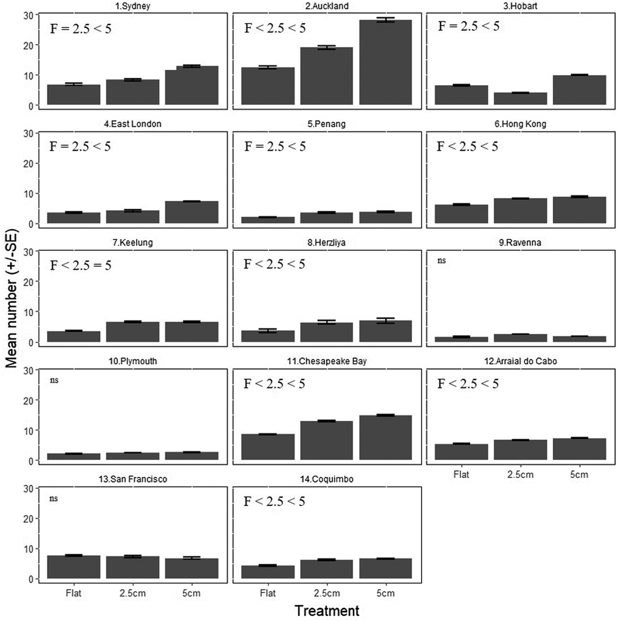

**FIGURE 3**

Effect of complexity (flat and 2.5‐ or 5‐cm complex tiles) on the mean (± *SE*) total taxa richness at each of 14 locations by realm (*n* = 1 or 2 sites per location). Significant differences (at α = .05) between flat (F), and 2.5‐cm (2.5) or 5‐cm (5) complex tiles are indicated by ‘>’ or ‘<’, with ‘ns’ or ‘=’ denoting treatments that did not significantly differ

TABLE 1. Overview of the post hoc tests for significant complexity by location interactions in the total richness and the richness and abundance of functional groups

[output not shown]

### Note

- Significant differences (at α = .05) between flat (F), and 2.5‐cm (2.5) or 5‐cm (5) complex tiles are indicated by ‘>’ or ‘<’, with ‘ns’ or ‘=’ denoting treatments that did not significantly differ. Locations are ordered by realm. Details of these analyses are given in Supporting Information Table S5a, Table S5b.

### 3.2 Effect of complexity on abundances

The effects of complexity varied among functional groups (algae, sessile and mobile invertebrates) and the 19 CATAMI groups, and within these groupings, according to location and/or site (Tables 1 and 2, Supporting Information Table S5b, Table S6a). The abundances (i.e., percentage cover or counts) of algae, sessile and mobile invertebrates (Table 1, Supporting Information S5) as well as that of encrusting macroalgae, bryozoans, sessile and mobile crustaceans, sessile and mobile molluscs, and sessile worms each displayed significant positive effects of the 2.5‐cm and/or the 5‐cm complex tiles relative to the flat tiles, at one or more locations, with non‐significant effects at the remaining (Table 2, Supporting Information Table S5b, Table S6a).

TABLE 2. Overview of the post hoc tests for significant complexity by location or complexity by site(location) interactions in the abundance of CATAMI groups

[output not shown]

### Note

- Significant differences (at α = .05) between flat (F), and 2.5‐cm (2.5) or 5‐cm (5) complex tiles are denoted with ‘>’ or ‘<’, with ‘ns’ or ‘=’ denoting treatments that did not differ. Locations are ordered by realm. Details of these analyses are given in Supporting Information Table S5a, Table S5b.

The abundances of mobile crustaceans and mobile molluscs showed significant positive effects of either the 2.5‐cm and/or 5‐cm tiles compared with the flat tiles, at some sites, but these differences were not consistent between sites nested within locations (Tables 2, Supporting Information Table S6a). The effects of complexity were, among locations, spatially variable in both occurrence and direction for filamentous/filiform macroalgae cover and mobile worm abundances and between sites for foliose macroalgae cover (Table 2, Supporting Information Table S6a). Although present on tiles, globose saccate macroalgae, articulated calcareous macroalgae, ascidians, cnidarians, sponges, hexapods, arthropods and echinoderms displayed patterns in abundance that did not respond to complexity, at any of the sites or locations (Table 2, Supporting Information Table S6a).

### 3.3 Correlates of spatial variation in effects of complexity

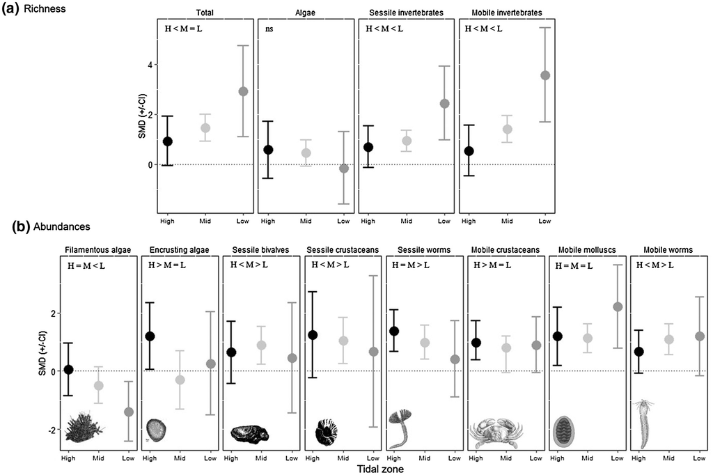

**FIGURE 4**

Effects of tidal zones on the standard mean differences (SMD; ± confidence interval) in (a) richness of total taxa, algae, sessile invertebrates and mobile invertebrates and (b) abundances (percentage cover or abundance) of key Collaborative and Automated Tools for Analysis of Marine Imagery groups between 5‐cm complex and flat tiles (high *n* = 5 sites, mid *n* = 18 sites and low *n* = 4 sites). Effects are significant if the confidence intervals do not overlap zero (dashed line). Significant differences (at α = .05) between high (H), and mid (M) or low (L) tidal zones are indicated by ‘>’ or ‘<’ or ‘=’ denoting treatments that did not significantly differ

The SMD of the richness of sessile invertebrate species between the 5‐cm complex and flat tiles increased with distance from the nearest marina or port. However, the SMD for other groups was unaffected by this variable (Supporting Information Table S7b). The SMD of total taxa richness significantly decreased with latitude (Figure 5), as did abundance of molluscs, while conversely, SMD of percentage cover of sessile bivalves increased with latitude (Supporting Information Table S7c). All other groups were unaffected by latitude (Supporting Information Table S7c).

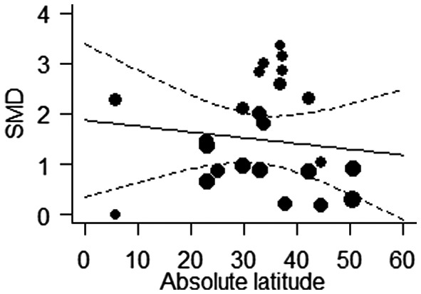

**FIGURE 5**

Effects of absolute latitude on the standard mean differences (SMD) in total taxa between 5‐cm complex and flat tiles (*n* = 27 sites), where the size of the circle varies according to the variance

## 4 DISCUSSION

Whereas the effects of the complex tiles on the richness and abundance of invertebrate groups were, where present, positive, the effects of the complex tiles on the richness and abundance of algae were highly variable, not only in occurrence, but also direction. The sessile invertebrate groups that responded most positively to the crevices and ridges provided by this study were taxa that are limited to shaded and moist low intertidal and subtidal shores (such as bryozoans; Miller & Etter, 2008), and taxa commonly targeted by benthic predators (e.g., molluscs, crustaceans, worms; Janssen et al., 2007; Strain, Morris, et al., 2018). In contrast, the mobile invertebrates that responded positively were taxa that could rapidly colonize by migration from nearby habitats (e.g., mobile molluscs and crustaceans; Martins et al., 2010). These taxa were predominantly found in the protective crevices of the complex tiles, suggesting that the provision of refugia could have played an important role (Strain et al., 2020). Filamentous and foliose macroalgae were negatively affected by complexity at some sites, despite the overall greater surface area of complex tiles. This may be because light in the crevices was insufficient to meet the needs of these taxa, which have high light requirements (Markager & Sand‐Jensen, 1992), or alternatively because of enhanced top–down control by the abundant grazer communities in the crevices. Encrusting algae, which have low light requirements (Markager & Sand‐Jensen, 1992) and a tough thallus that deters grazers (Bertness et al., 1983), were the only algal group to consistently respond positively to complexity.

Thermal and desiccation stress have long been implicated in setting the upper distributional limits of organisms intertidally (Harley, 2003; Wolcott, 1973) while classically, the lower distributional limits are thought to be set by biological interactions such as competition and predation (Connell, 1961). Consistent with this thinking and previous within‐site comparisons of complexity–biodiversity relationships among elevations (Cordell et al., 2017), we found the effects of added complexity on taxa richness and abundance of colonizing organisms differed among tidal elevations, as well as among functional groups. Total taxa richness and the richness of sessile and mobile invertebrates responded most strongly to complexity in the low intertidal zone, but the richness and abundances of algae, and abundances of sessile invertebrates responded more strongly in the mid and high intertidal zones. In the low intertidal, the crevices on complex tiles may provide refuge to invertebrate taxa from large‐bodied marine predators, such as fish, which can exert considerable top–down control on the communities of coastal structures (Connell & Anderson, 1999), and/or from wave exposure that can challenge the attachment strength of organisms and interfere with feeding behaviour (Bulleri & Chapman, 2010; Moschella et al., 2005). In the high and mid intertidal, on artificial coastal defences as on natural rocky shores, cool and shaded crevices could influence the richness and abundances of algae and the abundances of invertebrates by providing refuge from extreme temperatures and desiccation at low tide (Chapman & Blockley, 2009; Strain et al., 2020).

Additionally, we found evidence for latitudinal variation in the effects of complexity on total taxa richness and the abundance of some invertebrate groups. Complexity had the greatest effects on the total richness of taxa and the abundances of mobile molluscs at low latitudes, where average temperatures, primary productivity as well as taxa richness and abundance are generally highest (Hillebrand, 2004). However, the cover of sessile molluscs displayed the reverse pattern of greater effects of complexity at higher latitudes, where average temperatures and the percentage cover of sessile invertebrates were lower. These results are consistent with other studies that have demonstrated positive effects of complexity on the richness or diversity of invertebrates at tropical latitudes in intertidal systems (Menge & Lubchenco, 1981). Latitudinal variation in the effects of complexity likely reflects spatial variation in the local species pool, functional group identity and species recruitment, predation, and growth rates.

Despite our hypothesis that pollutants would override the effects of complexity, proximity of sites to marinas and port facilities, which are commonly highly contaminated (Adamo et al., 2005; Rivero et al., 2013), explained little of the variation in effects of complexity for most groups of algae and invertebrates. There was, however, a positive effect of the distance to the nearest port or marina on the relationship between complexity and richness of sessile invertebrates. Although our study did not document spatial variation in the size of the species pool of available colonists, the positive relationship between distance from boating facilities and effects of complexity on sessile invertebrates is consistent with the contaminants associated with boating facilities adversely impacting the native species pool on which complexity can act. Heavy metals, such as copper, either historically or presently used in antifouling paints, can negatively impact native biodiversity (Dafforn et al., 2011; Kinsella & Crowe, 2016). Previous studies have demonstrated these contaminants can also enhance the richness and abundances of invasive species (Marraffini et al., 2017; Piola et al., 2009); thus complexity could facilitate the increase of the non‐endemic species pool. Studies directly manipulating contamination inside and outside harbours would be required to establish the importance of this factor as a moderator of complexity effects.

Our results support previous suggestions that the addition of complexity to the homogenous, flat surfaces of coastal defence structures has the potential to improve ecological outcomes (O’Shaughnessy et al., 2020). As compared to the natural habitats they replace, topographically simple artificial structures commonly support reduced native biodiversity (Airoldi et al., 2015). Eco‐engineering complexity and missing microhabitats on these artificial structures to enhance the biodiversity and ecosystem functioning of their communities, is increasingly common. However, scientific studies providing the evidence base for this rapidly growing field are often poorly replicated and carried out over small spatial and temporal scales (Chapman et al., 2018; Firth et al., 2020). Global integration of small‐scale ecological experiments such as those conducted here can be useful in identifying appropriate eco‐engineering approaches before they are scaled up. Our study provides the most geographically comprehensive test of the effects of complexity on the biodiversity of coastal defence structures across the globe. We clearly demonstrate that complexity can affect the richness and abundances of colonizing taxa, and despite large biogeographic variation in the identity of taxa present, these effects are largely of a consistent and positive direction for particular functional groups across the globe.

Despite the generally positive effects of complexity, we found that the magnitude of these varied spatially from negligible to strongly positive (or in the case of some algae, negative). This is an important result as it suggests that economically costly eco‐engineering interventions may have negligible benefit at some locations and may even negatively influence some functional groups if applied blindly. Effective eco‐engineering requires understanding of the key environmental stressors that may be mitigated and the functional traits of taxa that are being targeted for enhancement. By designing microhabitats with the niches of target functional groups in mind, the benefits of complexity additions to structures may be maximized. Critically, the finding that the effect of complexity varied among locations, tidal zones and with latitude, highlights the importance of understanding how the effects of complexity are shaped by the local abiotic and biotic environments before implementing eco‐engineering solutions – one size will not necessarily fit all. Manipulative experiments are now needed to confirm how specific environmental and biological factors mediate complexity–biodiversity relationships within urbanized marine settings and whether the effects of complexity identified over a 12‐month period here persist over longer time‐scales. Moreover, to fully assess the biodiversity benefits of eco‐engineering interventions that add complexity, we would also need to compare the complex tiles to the surface of the coastal defence structure and adjacent natural rocky shores.

Eco‐engineering, like ecological restoration (Ewel, 1987), provides the ultimate test of ecological theory (Mitsch, 1996), by reassembling ecosystems from first principles. A cornerstone of community ecology has been the positive relationship between complexity and diversity (Dean & Connell, 1987; Kovalenko et al., 2012). Our global study challenges this paradigm in demonstrating that at patch‐scales complexity effects can range from positive to neutral to negative, depending upon location and functional group. General guidelines to enhance biodiversity in coastal constructions will benefit from a grounding in ecological theory that can help developers predict the influence of local environmental and biotic contexts (Mayer‐Pinto et al., 2019).

## ACKNOWLEDGMENTS

We thank the many people that helped in deploying and monitoring the experiment and funding bodies (see Supporting Information S9 for full details).

## APPENDIX A

## DATA SOURCES

Aguirre, J. D., Bollard‐Breen, B., Cameron, M., Constantine, R., Duffy, C. A., Dunphy, B., Hart, K., Hewitt, J. E., Jarvis, R. M., & Jeffs, A. (2016). Loved to pieces: Toward the sustainable management of the Waitematā Harbour and Hauraki Gulf. *Regional Studies in Marine Science*, *8*, 220–233.

Airoldi, L., Ponti, M., & Abbiati, M. (2016). Conservation challenges in human dominated seascapes: the harbour and coast of Ravenna. *Regional Studies in Marine Science*, *8*, 308–318.

Almeida, A., Souza, F. B., Gordon, D. P., & Vieira, L. M. (2015). The non‐indigenous bryozoan Triphyllozoon (Cheilostomata: Phidoloporidae) in the Atlantic: morphology and dispersion on the Brazilian coast. *Zoologia (Curitiba)*, *32*(6), 476–484.

Banks, J., Hedge, L., Hoisington, C., Strain, E., Steinberg, P., & Johnston, E. (2016). Sydney Harbour: Beautiful, diverse, valuable and pressured. *Regional Studies in Marine Science*, 8, 353–361.

Birch, G., Lee, J.‐H., Tanner, E., Fortune, J., Munksgaard, N., Whitehead, J., Coughanowr, C., Agius, J., Chrispijn, J., & Taylor, U. (2020). Sediment metal enrichment and ecological risk assessment of ten ports and estuaries in the World Harbours Project. *Marine Pollution Bulletin*, *155*, 111–129.

Bishop, M., & Hutchings, P. (2011). How useful are port surveys focused on target pest identification for exotic species management? *Marine Pollution Bulletin*, *62*(1), 36–42.

Bracewell, S. A., Spencer, M., Marrs, R. H., Iles, M., & Robinson, L. A. (2012). Cleft, crevice, or the inner thigh: ‘Another Place’ for the establishment of the invasive barnacle *Austrominius modestus* (Darwin, 1854). *PLoS ONE*, e48863.

Bugnot, A. B., Coleman, R. A., Figueira, W. F., & Marzinelli, E. M. (2014). Patterns of the non‐indigenous isopod *Cirolana harfordi* in Sydney Harbour. *PLoS ONE*, *9*(1), e86765.

Auckland C. (2012). Antifouling biocides in marinas: Measurement of copper concentrations and comparison to model predictions for eight Auckland sites. Technical report TR2012/033, Auckland, New Zealand.

Granthom‐Costa, L. V., Ferreira, C. G. W., & Dias, G. M. (2016). Biodiversity of ascidians in a heterogeneous bay from southeastern Brazil. *Management of Biological Invasions*, *7*(1), 5–12.

Knights, A. M., Firth, L. B., Thompson, R. C., Yunnie, A. L., Hiscock, K., & Hawkins, S. J. (2016). Plymouth—a world harbour through the ages. *Regional Studies in Marine Science*, *8*, 297–307.

Lai, R. W., Perkins, M. J., Ho, K. K., Astudillo, J. C., Yung, M. M., Russell, B. D., Williams, G. A., & Leung, K. M. (2016). Hong Kong's marine environments: History, challenges and opportunities. *Regional Studies in Marine Science*, *8*, 259–273.

Ling, S., Davey, A., Reeves, S., Gaylard, S., Davies, P., Stuart‐Smith, R., & Edgar, G. (2018). Pollution signature for temperate reef biodiversity is short and simple. *Marine Pollution Bulletin*, *130*, 159–169.

López, M. S., Lavrado, H. P., & Coutinho, R. (2014). Structure of intertidal sessile communities before and after the invasion of Isognomon bicolor (CB Adams, 1845)(Bivalvia, Isognomonidae) in southeastern Brazil. *Aquatic Invasions*, *9*(4), 457–465.

Macleod, C., & Coughanowr, C. (2019). Heavy metal pollution in the Derwent estuary: History, science and management*. Regional Studies in Marine Science, 33*, 100866.

O’Neil, J., Newton, R., Bone, E., Birney, L., Green, A., Merrick, B., Goodwin‐Segal, T., Moore, G., & Fraioli, A. (2020). Using urban harbors for experiential, environmental literacy: Case studies of New York and Chesapeake Bay. *Regional Studies in Marine Science*, *33*, 100886.

Blackmore, G., Rainbow, P. S. (2000). Barnacles as biomonitors of trace metal availabilities in Hong Kong coastal waters: 1998 update. In B. Morton (ed.), *The Marine Flora and Fauna of Hong Kong and Southern China* *V*, (p. 385). Hong Kong University Press.

Sliwa, C., Migus, S., McEnnulty, F., & Hayes, K. R. (2009). Marine bioinvasions in Australia. In G. Rilov, J. A. Crooks (eds.), *Biological invasions* *in marine ecosystems. Ecological Studies (Analysis and Synthesis) vol 204* (pp. 425–437). Berlin, Germany: Springer.

Soares‐Gomes, A., Da Gama, B. A. P., Neto, J. B., Freire, D., Cordeiro, R., Machado, W., Bernardes, M. C., Coutinho, R., Thompson, F. L., & Pereira, R. (2016). An environmental overview of Guanabara Bay, Rio de Janeiro. *Regional Studies in Marine Science*, *8*, 319–330.

Steger, K. K., & Gardner, J. P. (2007). Laboratory experiments on the effects of variable suspended sediment concentrations on the ecophysiology of the porcelain crab Petrolisthes elongatus (Milne Edwards, 1837). *Journal of Experimental Marine Biology and Ecology*, *344*(2), 181–192.

Tilbrook, K. J., & Gordon, D. P. (2016). Checklist of Singaporean Bryozoa and Entoprocta. *Raffles Bulletin of Zoology*, *34*, 593–603.

## BIOSKETCH

This research was conducted by members of the World Harbour Project, who ran a standardized experiment on the effects of complexity on biodiversity on marine artificial structures in 14 different urban bays and estuaries. The team was led by EMAS, who together with MJB and PDS conceived the initial idea and led the writing. LA and ELJ set up the Green Engineering group of the World Harbour Project. All authors contributed to collecting the data and to the revision of the manuscript.

[figure not shown]

January 2021

Pages 140-153

### Details

- © 2020 John Wiley & Sons Ltd

[figure not shown]